[figure not shown]

WI-442

Engine Wiring Harness and Transmission Cord

WIRING SYSTEM

66.Engine Wiring Harness and Transmission Cord

A: LOCATION

1. ENGINE TYPE FA

Connector Connecting to

No. Pole Color Area No. Description

AT1 3 GR D-4 Primary speed sensor

AT4 3 B D-5 Secondary speed sensor

AT5 3 GR D-5 Front wheel speed sensor

AT6 3 B D-4 Secondary pressure sensor

AT7 3 B C-5 Rear wheel speed sensor

E3 16 BR A-4 B22 Bulkhead wiring harness

E4 2 L A-3 Purge control solenoid valve 1

E5 2 GR B-2 Fuel injector No. 1

E6 2 GR B-3 Fuel injector No. 3

E8 2 B B-3 Engine coolant temperature sensor

E10 3 B B-4 Crankshaft position sensor

E11 1 — B-3 Oil pressure switch

E14 2 B B-3 Knock sensor RH

E16 2 GR B-4 Fuel injector No. 2

E17 2 GR B-4 Fuel injector No. 4

E18 6 GR A-3 EGR control valve

E24 6 B C-3 Front oxygen (A/F) sensor

E25 4 G C-4 Rear oxygen sensor

E31 3 B B-2 Ignition coil No. 1

E32 3 B B-4 Ignition coil No. 2

E33 3 B B-3 Ignition coil No. 3

E34 3 B B-5 Ignition coil No. 4

E35 3 GR B-4 Intake camshaft position sensor LH

E36 3 GR B-2 Intake camshaft position sensor RH

E37 2 B B-4 Intake oil control solenoid LH

E38 2 B B-2 Intake oil control solenoid RH

E48 2 B B-4 Knock sensor LH

E51 5 GR B-5 Tumble generator valve actuator LH

E52 2 B A-3 Purge control solenoid valve 2

E55 5 GR A-3 Tumble generator valve actuator RH

E57 6 B B-4 Electronic throttle control

E62 3 GR B-2 Exhaust camshaft position sensor RH

E63 2 B B-2 Exhaust oil control solenoid RH

E64 2 B B-2 Wastegate control solenoid valve

E65 3 GR C-4 Exhaust camshaft position sensor LH

E66 2 B C-4 Exhaust oil control solenoid LH

E75 2 B B-3 Engine oil temperature sensor

E124 4 B A-4 Manifold absolute pressure and intake air temperature sensor

E130 1 C-3 Oil level switch

E158 48 B A-2

ECM

E159 32 GR A-2

E160 2 B B-4 High-pressure fuel pump

E162 3 B A-3 Fuel pressure sensor

[figure not shown]

WI-443

Engine Wiring Harness and Transmission Cord

WIRING SYSTEM

T1 2 GR C-1 B24

Bulkhead wiring harness

T2 2 BR C-1 B25

T3 12 B C-4 B12

T4 20 GR C-4 B11

T7 9 B D-4 Inhibitor switch

T11 8 D-4 T31 Control valve body

T31 8 Y D-4 T11 Transmission cord

: White or natural color

Connector Connecting to

No. Pole Color Area No. Description

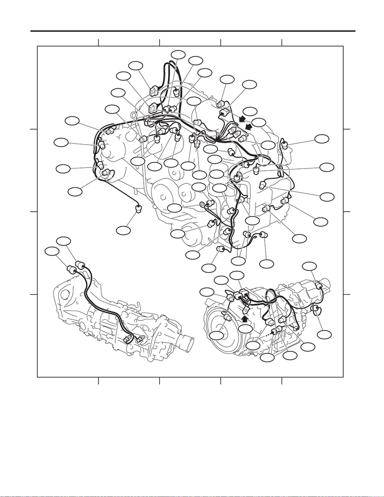

WI-444

Engine Wiring Harness and Transmission Cord

WIRING SYSTEM

WI-44620

12345

12345

A

B

C

D

A

B

C

D

< CVT >

< MT >

T2

T1

AT7

AT5

T11

T31

AT4

T7

E34

E32

E25

E35

E11

E75

E37

E65

E130

E66

E24

AT6

AT1

T4

T3

E51

E57

E10

E48

E16

E17

E160

E31

E36

E38

E63

E62

E33

E159

E158

E52

E55

E18

E124

E3

E4

E5

E64

E6

E8

E14

E162

GE-1

GE-2

GT

[figure not shown]

WI-445

Engine Wiring Harness and Transmission Cord

WIRING SYSTEM

2. ENGINE TYPE EJ

Connector Connecting to

No. Pole Color Area No. Description

E2 54 B A-3 B21 Bulkhead wiring harness

E4 2 B B-3 Purge control solenoid valve 1

E5 2 GR A-2 Fuel injector No. 1

E6 2 GR A-2 Fuel injector No. 3

E8 2 B B-3 Engine coolant temperature sensor

E10 2 GR B-3 Crankshaft position sensor

E11 1 — B-3 Oil pressure switch

E14 2 GR A-4 Knock sensor

E16 2 GR B-4 Fuel injector No. 2

E17 2 GR B-4 Fuel injector No. 4

E19 1 B-2 Power steering oil pressure switch

E21 3 B A-3 Manifold absolute pressure sensor

E31 3 GR B-2 Ignition coil No. 1

E32 3 GR C-4 Ignition coil No. 2

E33 3 GR B-2 Ignition coil No. 3

E34 3 GR B-4 Ignition coil No. 4

E35 3 GR B-4 Intake camshaft position sensor LH

E36 3 GR A-3 Intake camshaft position sensor RH

E37 2 L B-4 Intake oil flow control solenoid valve LH

E38 2 L A-2 Intake oil flow control solenoid valve RH

E40 6 B A-4 Secondary air combination valve LH

E41 2 B B-4 Secondary air combination valve RH

E51 5 GR B-5 Tumble generator valve actuator LH

E52 2 B A-3 Purge control solenoid valve 2

E55 5 GR A-2 Tumble generator valve actuator RH

E57 6 B A-3 Electronic throttle control

E62 3 GR B-2 Exhaust camshaft position sensor RH

E63 2 L B-2 Exhaust oil flow control solenoid valve RH

E64 2 L A-3 Wastegate control solenoid valve

E65 3 GR C-4 Exhaust camshaft position sensor LH

E66 2 L C-4 Exhaust oil flow control solenoid valve LH

E80 2 GR A-3 Leak diagnosis connector 1

E87 2 GR A-2 Leak diagnosis connector 2

T1 2 GR D-4 T13

Transmission cord

T2 2 BR D-4 T12

T5 4 GR D-3 B19 Bulkhead wiring harness

T6 4 GR D-4 Rear oxygen sensor

T9 6 GR D-3 B128 Bulkhead wiring harness

T12 2 BR D-3 T2 Neutral position switch 1

T13 2 GR D-3 T1 Back-up light switch

T16 2 D-3 T17 Center differential

T17 2 D-4 T16 Transmission cord

White or natural color

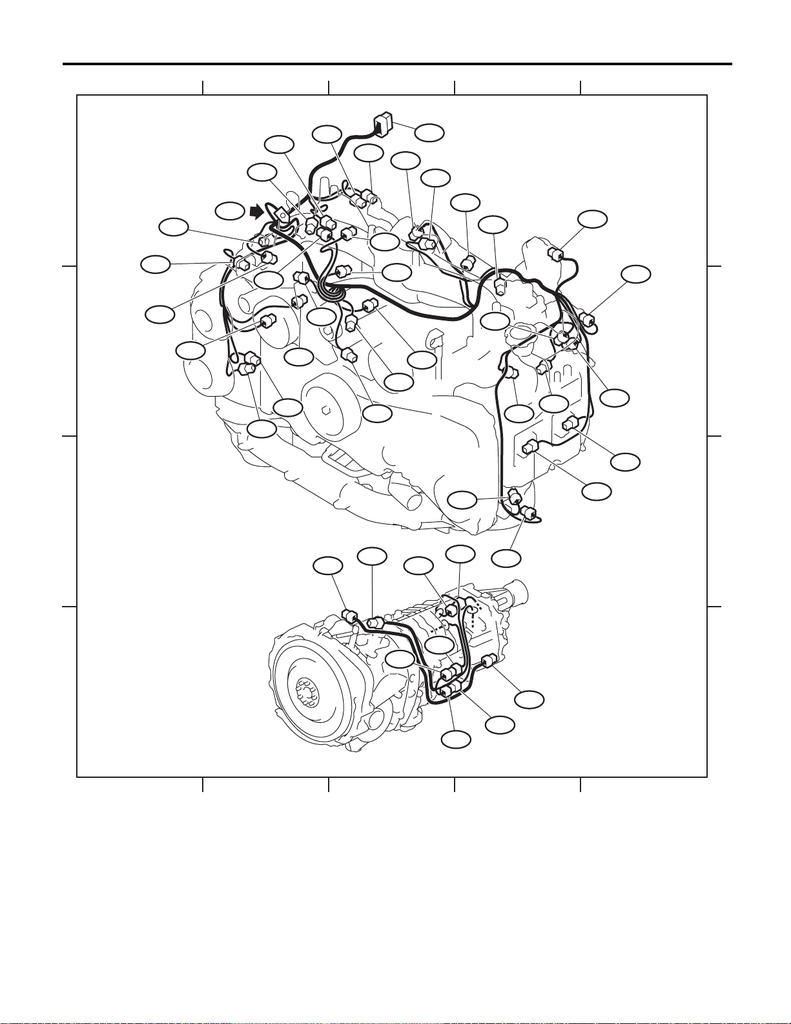

WI-446

Engine Wiring Harness and Transmission Cord

WIRING SYSTEM

WI-44621

12345

12345

A

B

C

D

A

B

C

D

< MT >

E38

E5

E55

E62

E31

E33

E63

E11

E10

E4

E52

E87

E8

E19

E57

E21

E64

E6

E36

E80

E2

E14

E35

E41

E40

E51

E17

E16

E37

E32

E66

E65

T17

T16

T2

T6

T12

T1

T13

T9

T5

E34

GE-3